# CIND 820 - Big Data Analytics Project

# Initial Analysis

### 500728133

Room Occupancy Estimation is a data set for estimating the precise number of occupants in a room using non-intrusive environmental sensors like temperature, light, sound, CO2 and PIR.The data set is available from the UC Irvine Machine Learning Repository (https://archive.ics.uci.edu/dataset/864/room+occupancy+estimation) in CSV format.

## Univariate Analysis

Create a data frame of the Room Occupancy Estimation dataset. Display the names of the columns.

```r
# Import the Occupancy_Estimation.csv file
occupancy_estimation <- read.csv("Occupancy_Estimation.csv")

# Display the names of the columns
names(occupancy_estimation)
```

```
##  [1] "Date"                 "Time"                 "S1_Temp"
##  [4] "S2_Temp"              "S3_Temp"              "S4_Temp"
##  [7] "S1_Light"             "S2_Light"             "S3_Light"
## [10] "S4_Light"             "S1_Sound"             "S2_Sound"
## [13] "S3_Sound"             "S4_Sound"             "S5_CO2"
## [16] "S5_CO2_Slope"         "S6_PIR"               "S7_PIR"
## [19] "Room_Occupancy_Count"
```

Rename the Room_Occupancy_Count column

```r
names(occupancy_estimation)[19] <- "Occupancy_Count"
names(occupancy_estimation)
```

```
##  [1] "Date"            "Time"            "S1_Temp"         "S2_Temp"
##  [5] "S3_Temp"         "S4_Temp"         "S1_Light"        "S2_Light"
##  [9] "S3_Light"        "S4_Light"        "S1_Sound"        "S2_Sound"
## [13] "S3_Sound"        "S4_Sound"        "S5_CO2"          "S5_CO2_Slope"
## [17] "S6_PIR"          "S7_PIR"          "Occupancy_Count"
```

Check the data types of the attributes.

```r
# Check the data types of the attributes
str(occupancy_estimation)
```

```
## 'data.frame':    10129 obs. of  19 variables:
##  $ Date           : chr  "2017/12/22" "2017/12/22" "2017/12/22" "2017/12/22" ...
##  $ Time           : chr  "10:49:41" "10:50:12" "10:50:42" "10:51:13" ...
##  $ S1_Temp        : num  24.9 24.9 25 25 25 ...
##  $ S2_Temp        : num  24.8 24.8 24.8 24.8 24.8 ...
##  $ S3_Temp        : num  24.6 24.6 24.5 24.6 24.6 ...
##  $ S4_Temp        : num  25.4 25.4 25.4 25.4 25.4 ...
##  $ S1_Light       : int  121 121 121 121 121 121 120 121 122 101 ...
##  $ S2_Light       : int  34 33 34 34 34 34 34 34 35 34 ...
##  $ S3_Light       : int  53 53 53 53 54 54 54 54 56 57 ...
##  $ S4_Light       : int  40 40 40 40 40 40 40 41 43 43 ...
##  $ S1_Sound       : num  0.08 0.93 0.43 0.41 0.18 0.13 1.39 0.09 0.09 3.84 ...
##  $ S2_Sound       : num  0.19 0.05 0.11 0.1 0.06 0.06 0.32 0.06 0.05 0.64 ...
##  $ S3_Sound       : num  0.06 0.06 0.08 0.1 0.06 0.06 0.43 0.09 0.06 0.48 ...
##  $ S4_Sound       : num  0.06 0.06 0.06 0.09 0.06 0.07 0.06 0.05 0.13 0.39 ...
##  $ S5_CO2         : int  390 390 390 390 390 390 390 390 390 390 ...
##  $ S5_CO2_Slope   : num  0.769 0.646 0.519 0.388 0.254 ...
##  $ S6_PIR         : int  0 0 0 0 0 0 1 0 0 1 ...
##  $ S7_PIR         : int  0 0 0 0 0 0 0 0 0 1 ...
##  $ Occupancy_Count: int  1 1 1 1 1 1 1 1 1 1 ...
```

Run a summary statistics of the dataset.

```r
# Run a summary statistics of the numeric variables
summary(occupancy_estimation[c("S1_Temp", "S2_Temp","S3_Temp", "S4_Temp",
                               "S1_Light", "S2_Light","S3_Light", "S4_Light",
                               "S1_Sound", "S2_Sound","S3_Sound", "S4_Sound",
                               "S5_CO2", "S5_CO2_Slope")])
```

```
##     S1_Temp         S2_Temp         S3_Temp         S4_Temp
##  Min.   :24.94   Min.   :24.75   Min.   :24.44   Min.   :24.94
##  1st Qu.:25.19   1st Qu.:25.19   1st Qu.:24.69   1st Qu.:25.44
##  Median :25.38   Median :25.38   Median :24.94   Median :25.75
##  Mean   :25.45   Mean   :25.55   Mean   :25.06   Mean   :25.75
##  3rd Qu.:25.63   3rd Qu.:25.63   3rd Qu.:25.38   3rd Qu.:26.00
##  Max.   :26.38   Max.   :29.00   Max.   :26.19   Max.   :26.56
##     S1_Light         S2_Light         S3_Light         S4_Light
##  Min.   :  0.00   Min.   :  0.00   Min.   :  0.00   Min.   : 0.00
##  1st Qu.:  0.00   1st Qu.:  0.00   1st Qu.:  0.00   1st Qu.: 0.00
##  Median :  0.00   Median :  0.00   Median :  0.00   Median : 0.00
##  Mean   : 25.45   Mean   : 26.02   Mean   : 34.25   Mean   :13.22
##  3rd Qu.: 12.00   3rd Qu.: 14.00   3rd Qu.: 50.00   3rd Qu.:22.00
##  Max.   :165.00   Max.   :258.00   Max.   :280.00   Max.   :74.00
##     S1_Sound         S2_Sound         S3_Sound         S4_Sound
##  Min.   :0.0600   Min.   :0.0400   Min.   :0.0400   Min.   :0.0500
##  1st Qu.:0.0700   1st Qu.:0.0500   1st Qu.:0.0600   1st Qu.:0.0600
##  Median :0.0800   Median :0.0500   Median :0.0600   Median :0.0800
##  Mean   :0.1682   Mean   :0.1201   Mean   :0.1581   Mean   :0.1038
##  3rd Qu.:0.0800   3rd Qu.:0.0600   3rd Qu.:0.0700   3rd Qu.:0.1000
##  Max.   :3.8800   Max.   :3.4400   Max.   :3.6700   Max.   :3.4000
##      S5_CO2        S5_CO2_Slope
##  Min.   : 345.0   Min.   :-6.29615
##  1st Qu.: 355.0   1st Qu.:-0.04615
##  Median : 360.0   Median : 0.00000
##  Mean   : 460.9   Mean   :-0.00483
##  3rd Qu.: 465.0   3rd Qu.: 0.00000
##  Max.   :1270.0   Max.   : 8.98077
```

Check for missing values in the data set.

```r
# Check the missing values in the data set
sum(is.na(occupancy_estimation))
```

```
## [1] 0
```

There are no missing values in the data set.

The Date variable is seen as a character string. Make it a date. Check the data types of the attributes.

```r
# Convert Date variable to a date
occupancy_estimation$Date <- as.Date(occupancy_estimation$Date, format="%Y/%m/%d")

# Check the data types of the attributes
str(occupancy_estimation)
```

```
## 'data.frame':    10129 obs. of  19 variables:
##  $ Date           : Date, format: "2017-12-22" "2017-12-22" ...
##  $ Time           : chr  "10:49:41" "10:50:12" "10:50:42" "10:51:13" ...
##  $ S1_Temp        : num  24.9 24.9 25 25 25 ...
##  $ S2_Temp        : num  24.8 24.8 24.8 24.8 24.8 ...
##  $ S3_Temp        : num  24.6 24.6 24.5 24.6 24.6 ...
##  $ S4_Temp        : num  25.4 25.4 25.4 25.4 25.4 ...
##  $ S1_Light       : int  121 121 121 121 121 121 120 121 122 101 ...
##  $ S2_Light       : int  34 33 34 34 34 34 34 34 35 34 ...
##  $ S3_Light       : int  53 53 53 53 54 54 54 54 56 57 ...
##  $ S4_Light       : int  40 40 40 40 40 40 40 41 43 43 ...
##  $ S1_Sound       : num  0.08 0.93 0.43 0.41 0.18 0.13 1.39 0.09 0.09 3.84 ...
##  $ S2_Sound       : num  0.19 0.05 0.11 0.1 0.06 0.06 0.32 0.06 0.05 0.64 ...
##  $ S3_Sound       : num  0.06 0.06 0.08 0.1 0.06 0.06 0.43 0.09 0.06 0.48 ...
##  $ S4_Sound       : num  0.06 0.06 0.06 0.09 0.06 0.07 0.06 0.05 0.13 0.39 ...
##  $ S5_CO2         : int  390 390 390 390 390 390 390 390 390 390 ...
##  $ S5_CO2_Slope   : num  0.769 0.646 0.519 0.388 0.254 ...
##  $ S6_PIR         : int  0 0 0 0 0 0 1 0 0 1 ...
##  $ S7_PIR         : int  0 0 0 0 0 0 0 0 0 1 ...
##  $ Occupancy_Count: int  1 1 1 1 1 1 1 1 1 1 ...
```

Use a histogram to assess normality of the Temperature variables.

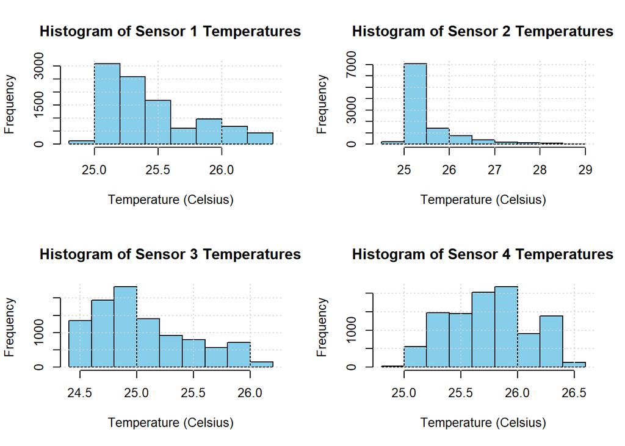

```r
par(mfrow=c(2,2))

# Check if the distribution of S1 Temperature is normally distributed
hist(occupancy_estimation$S1_Temp,
     xlab="Temperature (Celsius)",
     main="Histogram of Sensor 1 Temperatures",
     col="skyblue",
     border="black",
     breaks=8)
grid()

# Check if the distribution of S2 Temperature is normally distributed
hist(occupancy_estimation$S2_Temp,
     xlab="Temperature (Celsius)",
     main="Histogram of Sensor 2 Temperatures",
     col="skyblue",
     border="black",
     breaks=8)
grid()

# Check if the distribution of S3 Temperature is normally distributed
hist(occupancy_estimation$S3_Temp,
     xlab="Temperature (Celsius)",
     main="Histogram of Sensor 3 Temperatures",
     col="skyblue",
     border="black",
     breaks=8)
grid()

# Check if the distribution of S4 Temperature is normally distributed
hist(occupancy_estimation$S4_Temp,
     xlab="Temperature (Celsius)",
     main="Histogram of Sensor 4 Temperatures",
     col="skyblue",
     border="black",
     breaks=8)
grid()
```

```r
par(mfrow=c(1,1))
```

```r
# Normality test for sensor 4 temperature. Sample size must be between 3 and 5000.
temp <- subset(occupancy_estimation, Date=="2017-12-22" | Date=="2017-12-23" | Date=="2017-01-10") # Days with occupants

shapiro_test <- shapiro.test(temp$S4_Temp)
print(shapiro_test)
```

```
##
##  Shapiro-Wilk normality test
##
## data:  temp$S4_Temp
## W = 0.92296, p-value < 2.2e-16
```

```r
if (shapiro_test$p.value > 0.05) {
  print("Temperature data for sensor 4 is normally distributed")
} else {
  print("Temperature data for sensor 4 is not normally distributed")
}
```

```
## [1] "Temperature data for sensor 4 is not normally distributed"
```

Create a boxpot which shows the Temperature values of each sensor. Use different colors for each sensor.

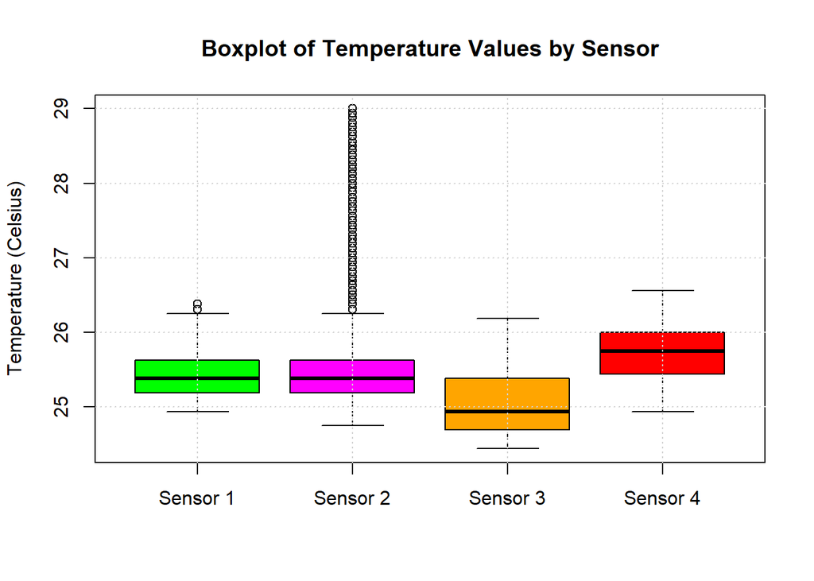

```r
# Create the boxplot
boxplot(occupancy_estimation$S1_Temp, occupancy_estimation$S2_Temp, occupancy_estimation$S3_Temp,
        occupancy_estimation$S4_Temp,
        names=c("Sensor 1", "Sensor 2", "Sensor 3", "Sensor 4"),
        col=c("green","magenta","orange","red"),
        ylab = "Temperature (Celsius)", main="Boxplot of Temperature Values by Sensor" )
grid()
```

Use a histogram to assess normality of the Light variables.

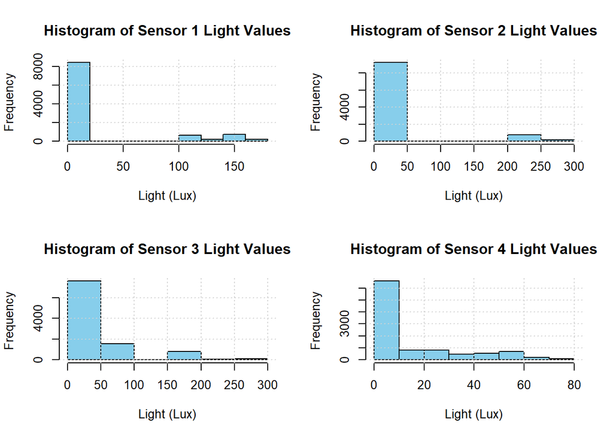

```r
par(mfrow=c(2,2))

# Check if the distribution of S1 Light is normally distributed
hist(occupancy_estimation$S1_Light,
     xlab="Light (Lux)",
     main="Histogram of Sensor 1 Light Values",
     col="skyblue",
     border="black",
     breaks=8)
grid()

# Check if the distribution of S2 Light is normally distributed
hist(occupancy_estimation$S2_Light,
     xlab="Light (Lux)",
     main="Histogram of Sensor 2 Light Values",
     col="skyblue",
     border="black",
     breaks=8)
grid()

# Check if the distribution of S3 Light is normally distributed
hist(occupancy_estimation$S3_Light,
     xlab="Light (Lux)",
     main="Histogram of Sensor 3 Light Values",
     col="skyblue",
     border="black",
     breaks=8)
grid()

# Check if the distribution of S4 Light is normally distributed
hist(occupancy_estimation$S4_Light,
     xlab="Light (Lux)",
     main="Histogram of Sensor 4 Light Values",
     col="skyblue",
     border="black",
     breaks=8)
grid()
```

```r
par(mfrow=c(1,1))
```

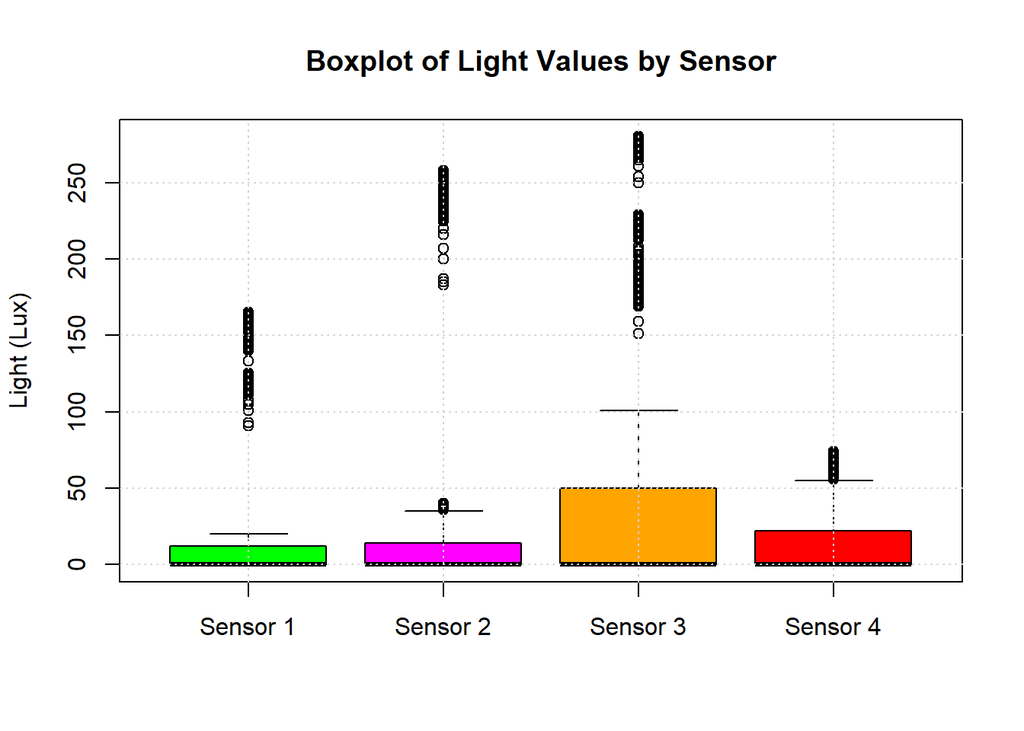

```r
# Create the boxplot
boxplot(occupancy_estimation$S1_Light, occupancy_estimation$S2_Light, occupancy_estimation$S3_Light,
        occupancy_estimation$S4_Light,
        names=c("Sensor 1", "Sensor 2", "Sensor 3", "Sensor 4"),
        col=c("green","magenta","orange","red"),
        ylab = "Light (Lux)", main="Boxplot of Light Values by Sensor" )
grid()
```

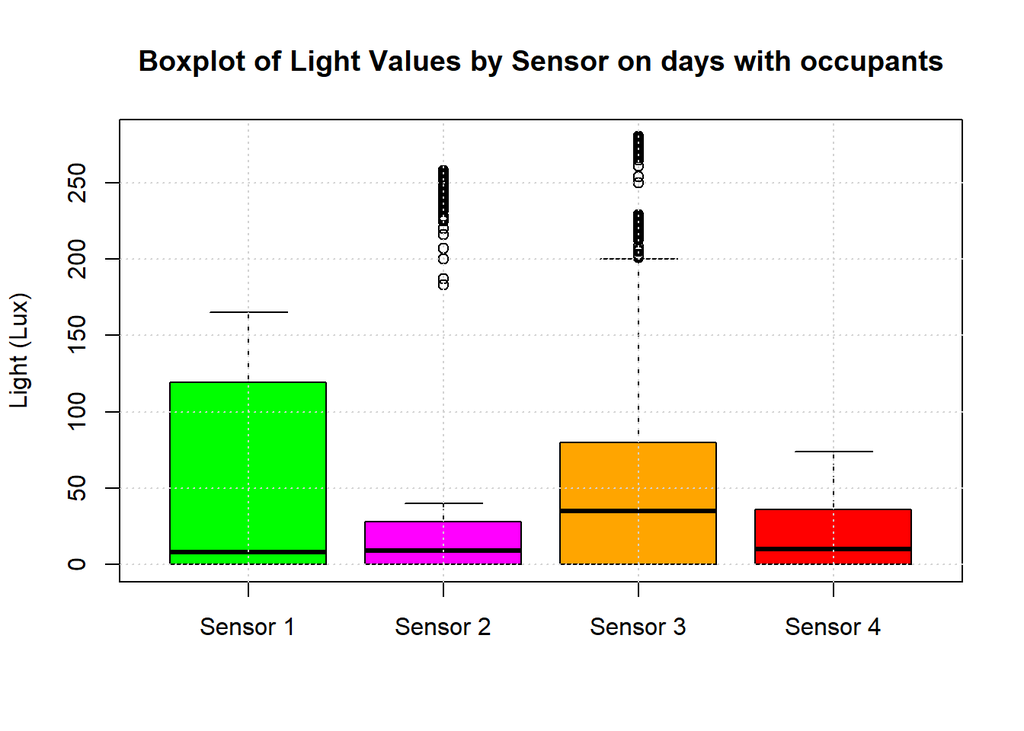

```r
# Consider only days with occupants
light <- subset(occupancy_estimation, Date=="2017-12-22" | Date=="2017-12-23" | Date=="2017-01-10") # Days with occupants

# Create the boxplot
boxplot(light$S1_Light, light$S2_Light, light$S3_Light, light$S4_Light,
        names=c("Sensor 1", "Sensor 2", "Sensor 3", "Sensor 4"),
        col=c("green","magenta","orange","red"),
        ylab = "Light (Lux)", main="Boxplot of Light Values by Sensor on days with occupants")
grid()
```

```r
# Normality test for sensor 4 light values. Sample size must be between 3 and 5000.
shapiro_test <- shapiro.test(light$S4_Light)
print(shapiro_test)
```

```
##
##  Shapiro-Wilk normality test
##
## data:  light$S4_Light
## W = 0.80273, p-value < 2.2e-16
```

```r
if (shapiro_test$p.value > 0.05) {
  print("Light data for sensor 4 is normally distributed")
} else {
  print("Light data for sensor 4 is not normally distributed")
}
```

```
## [1] "Light data for sensor 4 is not normally distributed"
```

Use a histogram to assess normality of the Sound variables.

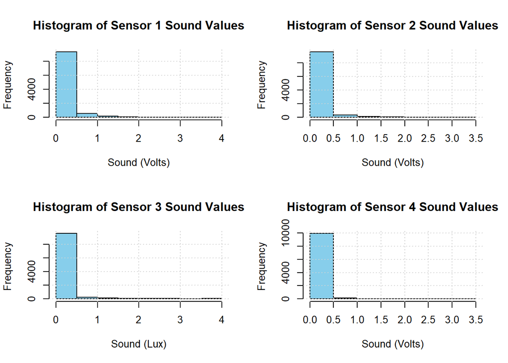

```r
par(mfrow=c(2,2))

# Check if the distribution of S1 Sound is normally distributed
hist(occupancy_estimation$S1_Sound,
     xlab="Sound (Volts)",
     main="Histogram of Sensor 1 Sound Values",
     col="skyblue",
     border="black",
     breaks=8)
grid()

# Check if the distribution of S2 Sound is normally distributed
hist(occupancy_estimation$S2_Sound,
     xlab="Sound (Volts)",
     main="Histogram of Sensor 2 Sound Values",
     col="skyblue",
     border="black",
     breaks=8)
grid()

# Check if the distribution of S3 Sound is normally distributed
hist(occupancy_estimation$S3_Sound,
     xlab="Sound (Lux)",
     main="Histogram of Sensor 3 Sound Values",
     col="skyblue",
     border="black",
     breaks=8)
grid()

# Check if the distribution of S4 Sound is normally distributed
hist(occupancy_estimation$S4_Sound,
     xlab="Sound (Volts)",
     main="Histogram of Sensor 4 Sound Values",
     col="skyblue",
     border="black",
     breaks=8)
grid()
```

```r
par(mfrow=c(1,1))
```

Create a boxpot which shows the Sound values of each sensor. Use different colors for each sensor.

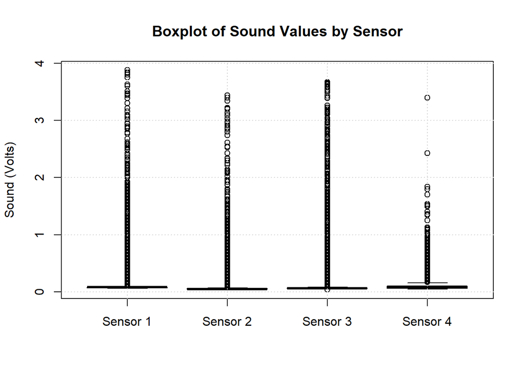

```r
# Create the boxplot
boxplot(occupancy_estimation$S1_Sound, occupancy_estimation$S2_Sound, occupancy_estimation$S3_Sound,
        occupancy_estimation$S4_Sound,
        names=c("Sensor 1", "Sensor 2", "Sensor 3", "Sensor 4"),
        col=c("green","magenta","orange","red"),
        ylab = "Sound (Volts)", main="Boxplot of Sound Values by Sensor" )
grid()
```

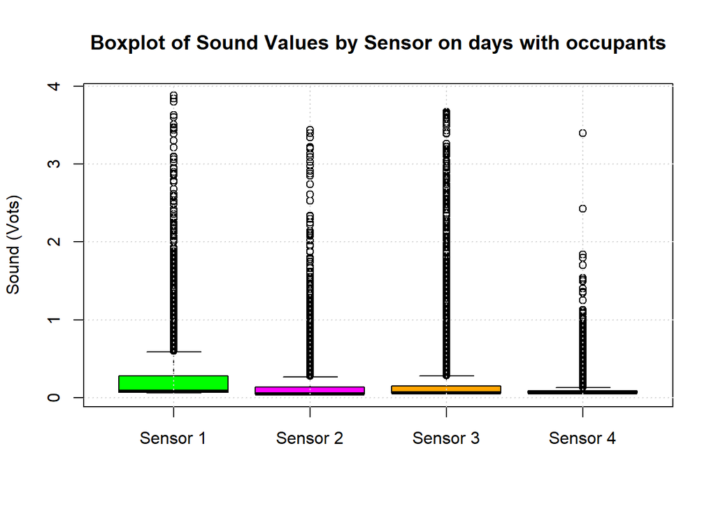

```r
# Consider only days with occupants
sound <- subset(occupancy_estimation, Date=="2017-12-22" | Date=="2017-12-23" | Date=="2017-01-10") # Days with occupants

# Create the boxplot
boxplot(sound$S1_Sound, sound$S2_Sound, sound$S3_Sound, sound$S4_Sound,
        names=c("Sensor 1", "Sensor 2", "Sensor 3", "Sensor 4"),
        col=c("green","magenta","orange","red"),
        ylab = "Sound (Vots)", main="Boxplot of Sound Values by Sensor on days with occupants")
grid()
```

Use a histogram to assess normality of the CO2 variables.

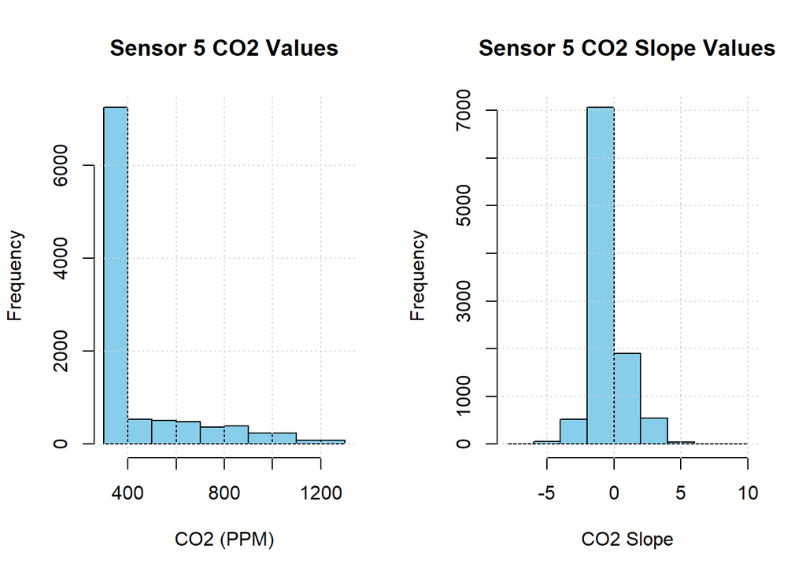

```r
par(mfrow=c(1,2))

# Check if the distribution of S5 CO2 is normally distributed
hist(occupancy_estimation$S5_CO2,
     xlab="CO2 (PPM)",
     main="Sensor 5 CO2 Values",
     col="skyblue",
     border="black",
     breaks=8)
grid()

# Check if the distribution of S2 CO2 Slope  is normally distributed
hist(occupancy_estimation$S5_CO2_Slope,
     xlab="CO2 Slope",
     main="Sensor 5 CO2 Slope Values",
     col="skyblue",
     border="black",
     breaks=8)
grid()
```

```r
par(mfrow=c(1,1))
```

Create a boxpot which shows the CO2 values.

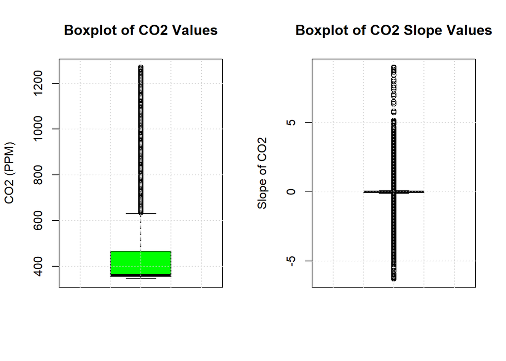

```r
par(mfrow=c(1,2))

# Create the boxplots

boxplot(occupancy_estimation$S5_CO2,
        names=c("CO2"),
        col=c("green"),
        ylab = "CO2 (PPM)", main="Boxplot of CO2 Values" )
grid()

boxplot(occupancy_estimation$S5_CO2_Slope,
        names=c("CO2"),
        col=c("green"),
        ylab = "Slope of CO2", main="Boxplot of CO2 Slope Values" )
grid()
```

```r
par(mfrow=c(1,1))
```

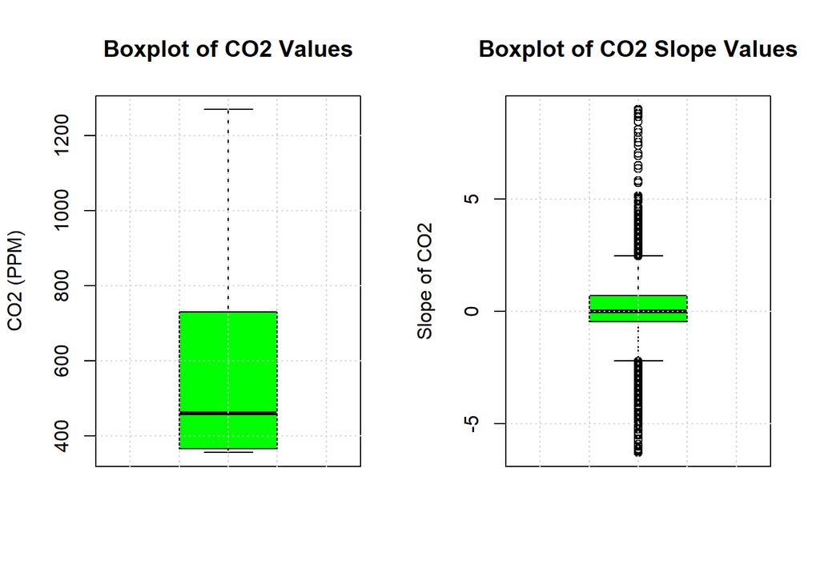

```r
# Consider only days with occupants
co2 <- subset(occupancy_estimation, Date=="2017-12-22" | Date=="2017-12-23" | Date=="2017-01-10") # Days with occupants

par(mfrow=c(1,2))

# Create the boxplots

boxplot(co2$S5_CO2,
        names=c("CO2"),
        col=c("green"),
        ylab = "CO2 (PPM)", main="Boxplot of CO2 Values" )
grid()

boxplot(co2$S5_CO2_Slope,
        names=c("CO2"),
        col=c("green"),
        ylab = "Slope of CO2", main="Boxplot of CO2 Slope Values" )
grid()
```

```r
par(mfrow=c(1,1))
```

```r
# Normality test for CO2 slope values. Sample size must be between 3 and 5000.
shapiro_test <- shapiro.test(co2$S5_CO2_Slope)
print(shapiro_test)
```

```
##
##  Shapiro-Wilk normality test
##
## data:  co2$S5_CO2_Slope
## W = 0.93606, p-value < 2.2e-16
```

```r
if (shapiro_test$p.value > 0.05) {
  print("CO2 Slope data is normally distributed")
} else {
  print("CO2 slope data is not normally distributed")
}
```

```
## [1] "CO2 slope data is not normally distributed"
```

Create a bar chart of the S6_PIR and S7_PIR variables

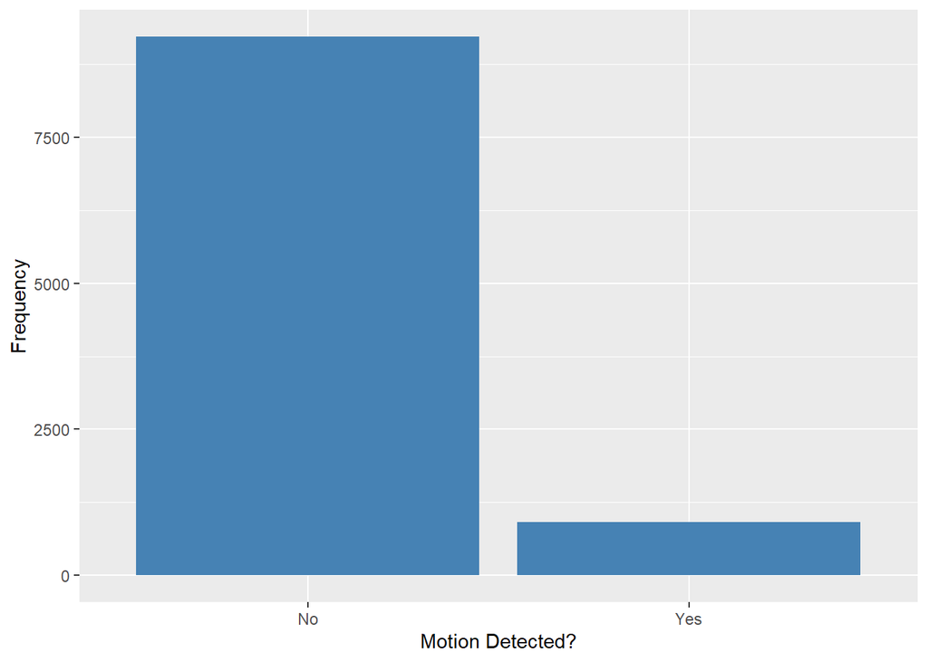

```r
library(ggplot2)
# Create factors for the S6_PIR and S7_PIR variables
S6_PIR_factor <- factor(occupancy_estimation$S6_PIR, levels=0:1,
                                      labels=c("No", "Yes"))
S7_PIR_factor <- factor(occupancy_estimation$S7_PIR, levels=0:1,
                                      labels=c("No", "Yes"))
# Create bar chart of the S6_PIR variable
ggplot(occupancy_estimation, aes(x=S6_PIR_factor)) +
  geom_bar(fill='steelblue') +
  labs(x='Motion Detected?', y='Frequency')
```

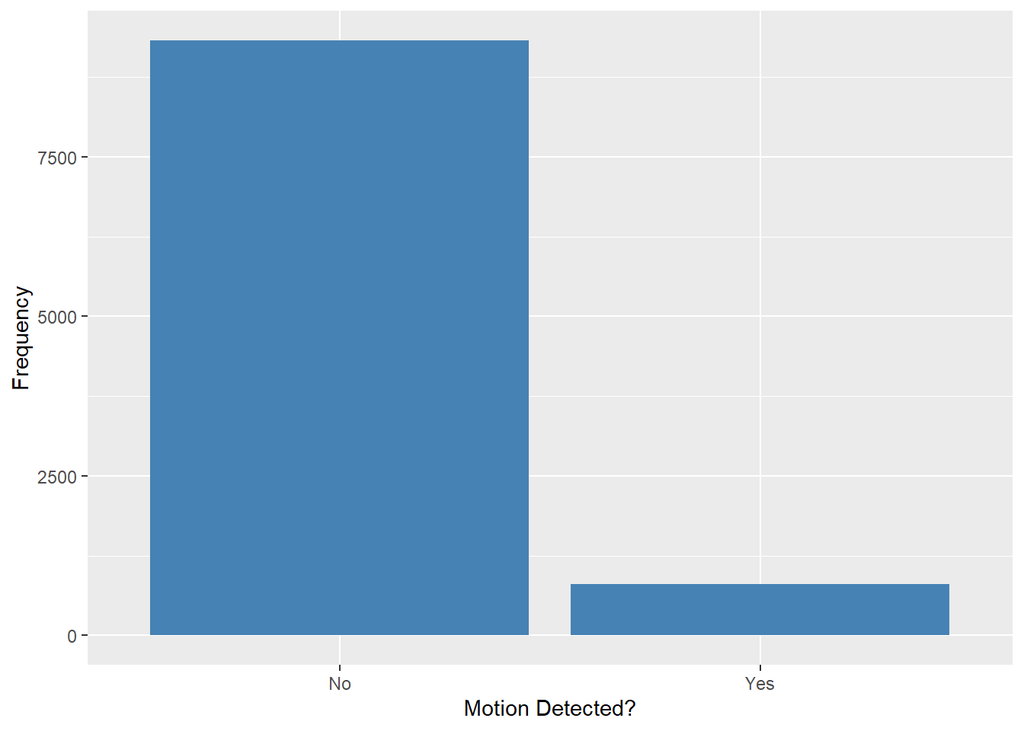

```r
# Create bar chart of the S7_PIR variable
ggplot(occupancy_estimation, aes(x=S7_PIR_factor)) +
  geom_bar(fill='steelblue') +
  labs(x='Motion Detected?', y='Frequency')
```

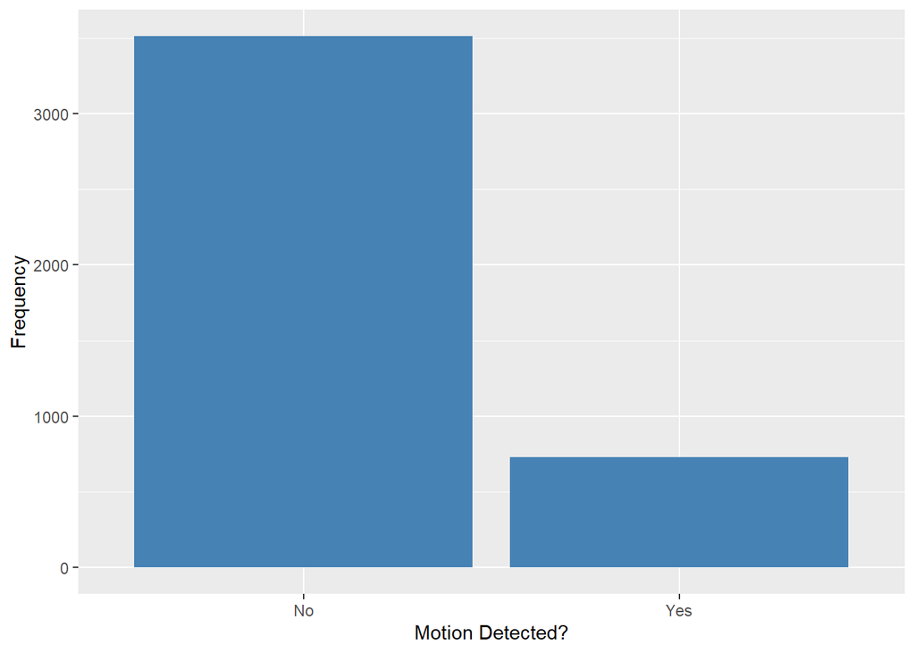

```r
# Consider only days with occupants
motion <- subset(occupancy_estimation, Date=="2017-12-22" | Date=="2017-12-23" | Date=="2017-01-10") # Days with occupants

# Create factors for the S6_PIR and S7_PIR variables
S6_PIR_factor <- factor(motion$S6_PIR, levels=0:1,
                                      labels=c("No", "Yes"))
S7_PIR_factor <- factor(motion$S7_PIR, levels=0:1,
                                      labels=c("No", "Yes"))

# Create bar chart of the S6_PIR variable
ggplot(motion, aes(x=S6_PIR_factor)) +
  geom_bar(fill='steelblue') +
  labs(x='Motion Detected?', y='Frequency')
```

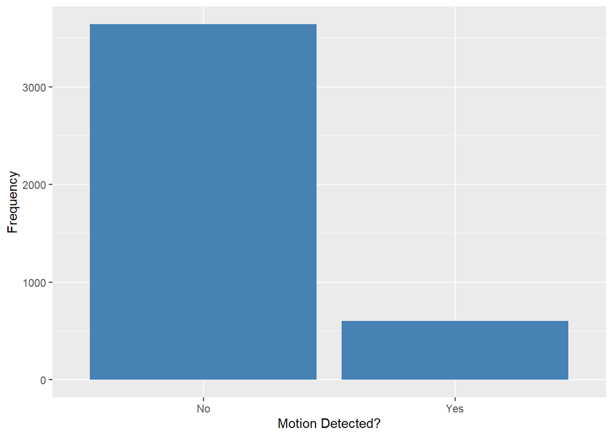

```r
# Create bar chart of the S7_PIR variable
ggplot(motion, aes(x=S7_PIR_factor)) +
  geom_bar(fill='steelblue') +
  labs(x='Motion Detected?', y='Frequency')
```

Create a bar chart of the Room Occupancy Count (target) variable

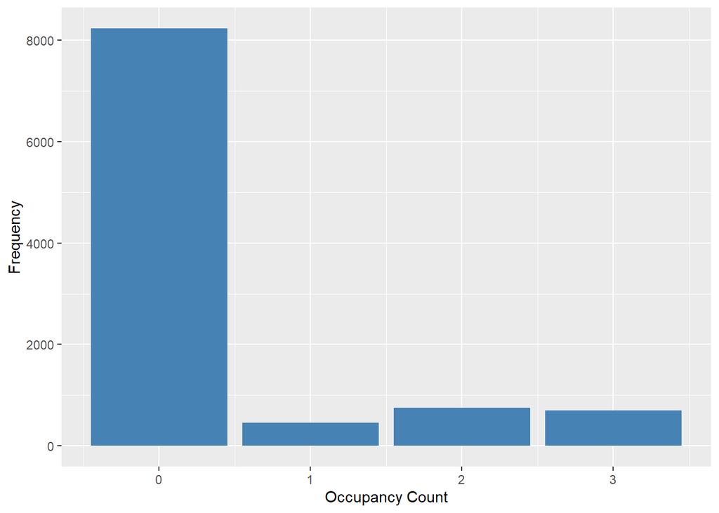

```r
library(ggplot2)

# Create bar chart of Room Occupancy Count
ggplot(occupancy_estimation, aes(x=Occupancy_Count)) +
  geom_bar(fill='steelblue') +
  labs(x='Occupancy Count', y='Frequency')
```

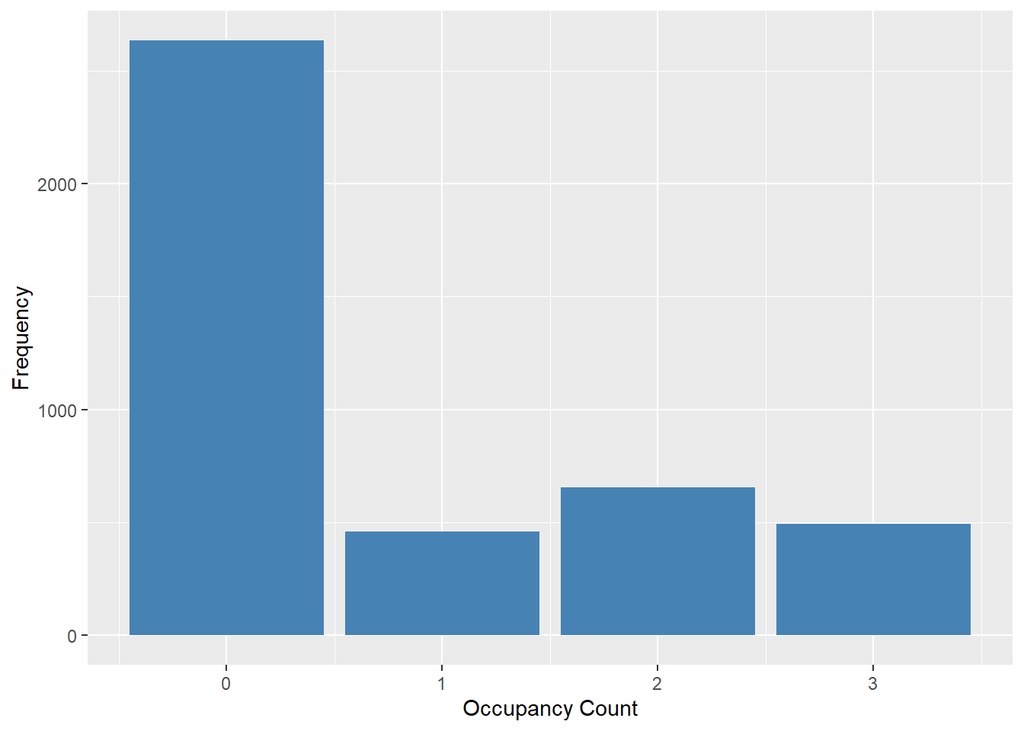

```r
# Consider only days with occupants
occupancy <- subset(occupancy_estimation, Date=="2017-12-22" | Date=="2017-12-23" | Date=="2017-01-10") # Days with occupant

# Create bar chart of Room Occupancy Count
ggplot(occupancy, aes(x=Occupancy_Count)) +
  geom_bar(fill='steelblue') +
  labs(x='Occupancy Count', y='Frequency')
```

## Bivariate Analysis

Create a scatter plot matrix of the numeric variables within the data set

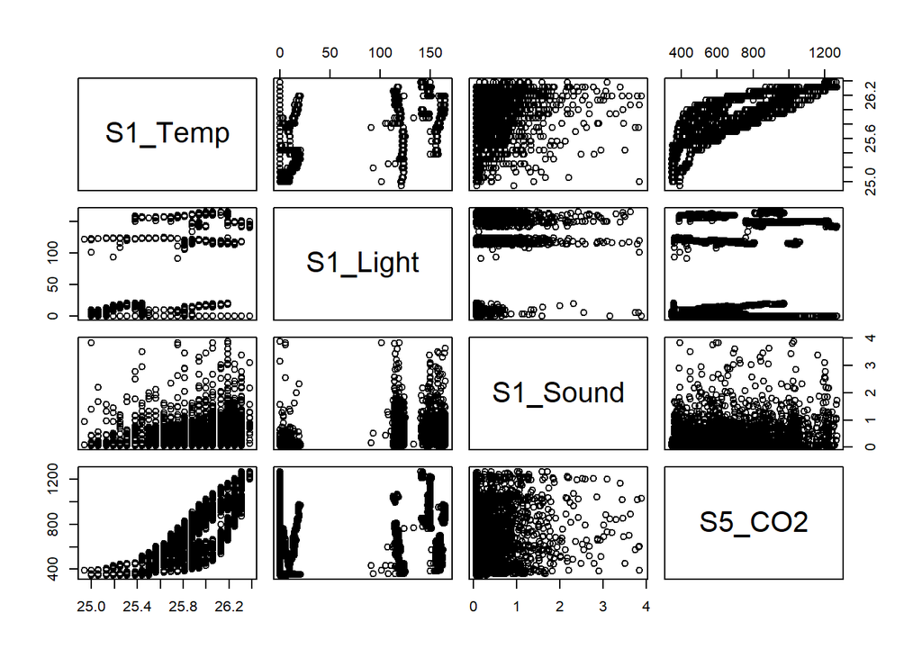

```r
# Create a scatter plot matrix of the temperature values
df <- c("S1_Temp", "S2_Temp", "S3_Temp", "S4_Temp")
#pairs(occupancy_estimation[df])

# Create a scatter plot matrix of the light values
df <- c("S1_Light", "S2_Light", "S3_Light", "S4_Light")
#pairs(occupancy_estimation[df])

# Create a scatter plot matrix of the sound values
df <- c("S1_Sound", "S2_Sound", "S3_Sound", "S4_Sound")
#pairs(occupancy_estimation[df])

# Create a scatter plot matrix of the CO2 values
df <- c("S5_CO2", "S5_CO2_Slope")
#pairs(occupancy_estimation[df])

# Create a scatter plot matrix of the S1 sensor and CO2 values
df <- c("S1_Temp", "S1_Light", "S1_Sound", "S5_CO2")
pairs(occupancy_estimation[df])
```

```r
# Create a scatter plot matrix of the S2 sensor and CO2 values
df <- c("S2_Temp", "S2_Light", "S2_Sound", "S5_CO2")
#pairs(occupancy_estimation[df])

# Create a scatter plot matrix of the S2 sensor and CO2 values
df <- c("S3_Temp", "S3_Light", "S3_Sound", "S5_CO2")
#pairs(occupancy_estimation[df])

# Create a scatter plot matrix of the S2 sensor and CO2 values
df <- c("S4_Temp", "S4_Light", "S4_Sound", "S5_CO2")
#pairs(occupancy_estimation[df])
```

Create a boxplot to display the distribution of room occupancy for each day

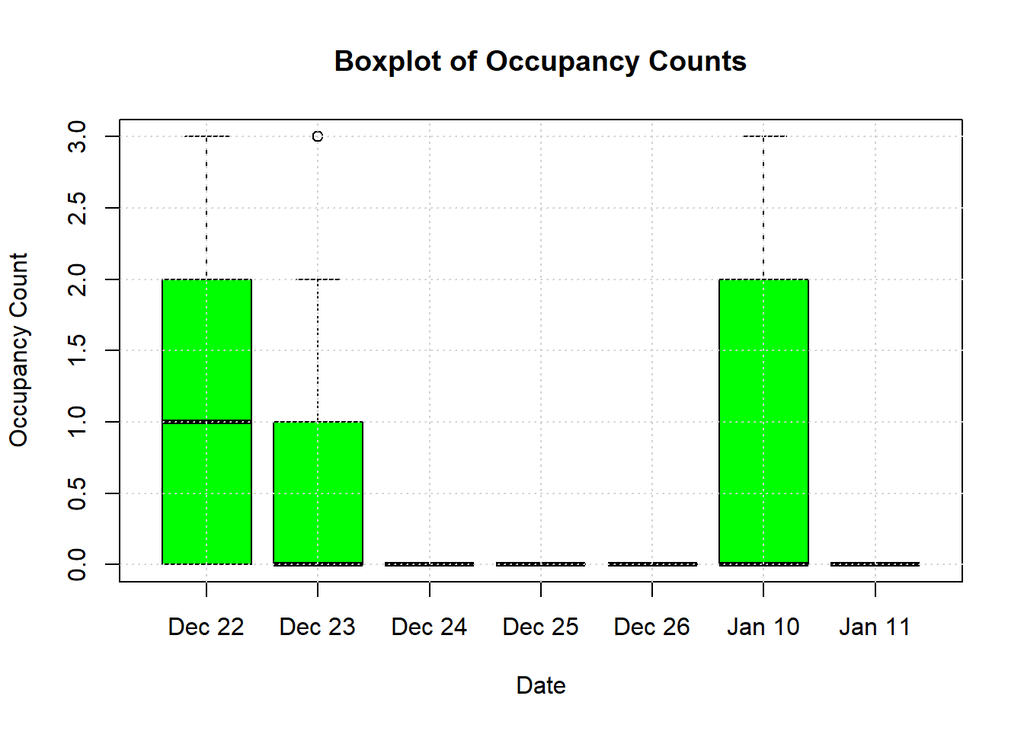

```r
boxplot(occupancy_estimation$Occupancy_Count ~ occupancy_estimation$Date,
        names=c("Dec 22","Dec 23", "Dec 24", "Dec 25", "Dec 26", "Jan 10", "Jan 11"),
        col=c("green"),
        xlab = "Date", ylab = "Occupancy Count", main="Boxplot of Occupancy Counts" )
grid()
```

Create a boxplot to display the distribution of CO2 for each day

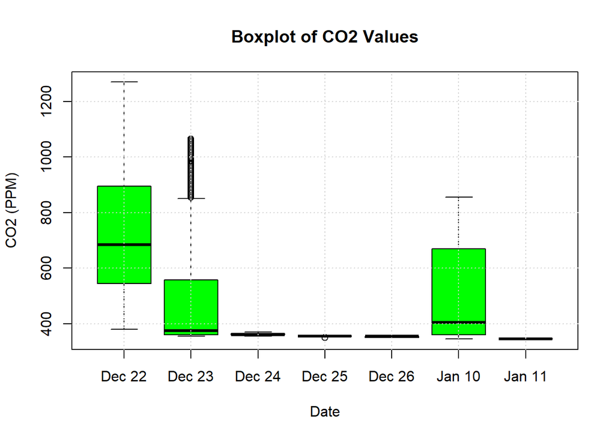

```r
# Create the boxplot
boxplot(occupancy_estimation$S5_CO2 ~ occupancy_estimation$Date,
        names=c("Dec 22","Dec 23", "Dec 24", "Dec 25", "Dec 26", "Jan 10", "Jan 11"),
        col=c("green"),
        xlab = "Date", ylab = "CO2 (PPM)", main="Boxplot of CO2 Values" )
grid()
```

Create a boxplot to display the distribution of temperature values each day

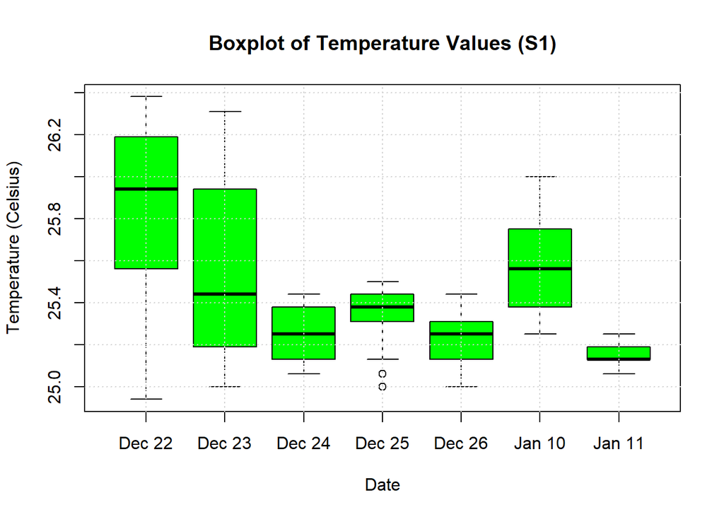

```r
# Create the boxplots

boxplot(occupancy_estimation$S1_Temp ~ occupancy_estimation$Date,
        names=c("Dec 22","Dec 23", "Dec 24", "Dec 25", "Dec 26", "Jan 10", "Jan 11"),
        col=c("green"),
        xlab = "Date", ylab = "Temperature (Celsius)", main="Boxplot of Temperature Values (S1)" )
grid()
```

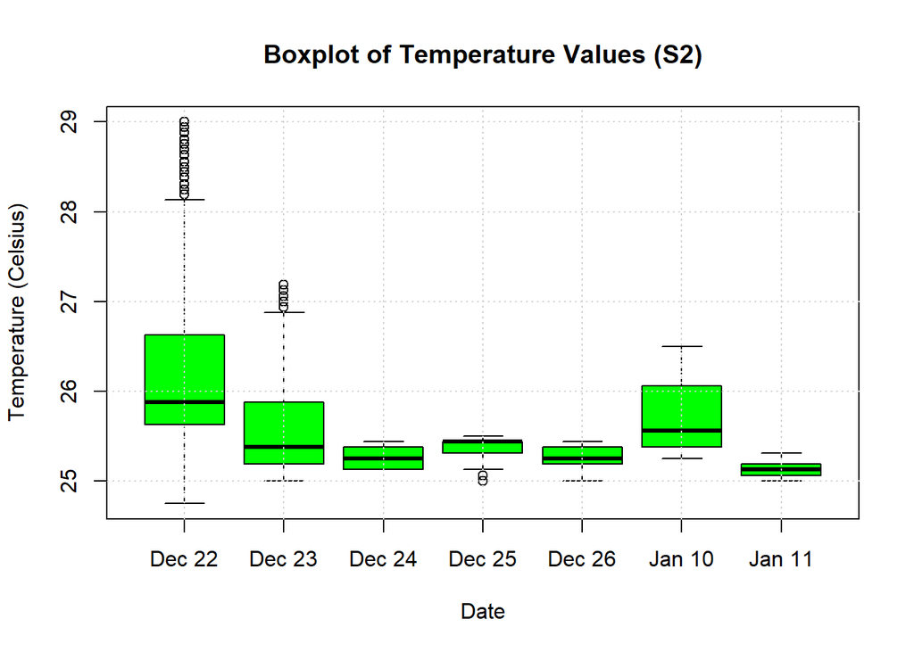

```r
boxplot(occupancy_estimation$S2_Temp ~ occupancy_estimation$Date,
        names=c("Dec 22","Dec 23", "Dec 24", "Dec 25", "Dec 26", "Jan 10", "Jan 11"),
        col=c("green"),
        xlab = "Date", ylab = "Temperature (Celsius)", main="Boxplot of Temperature Values (S2)" )
grid()
```

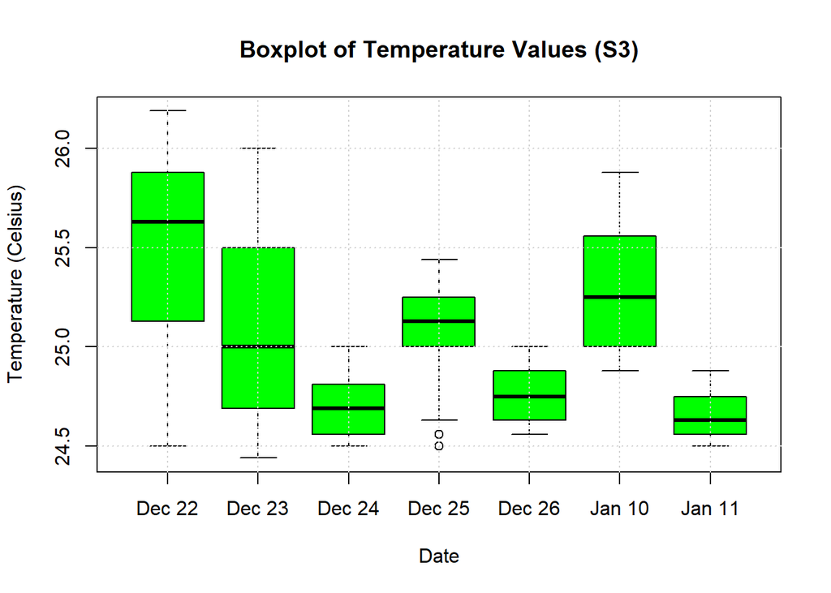

```r
boxplot(occupancy_estimation$S3_Temp ~ occupancy_estimation$Date,
        names=c("Dec 22","Dec 23", "Dec 24", "Dec 25", "Dec 26", "Jan 10", "Jan 11"),
        col=c("green"),
        xlab = "Date", ylab = "Temperature (Celsius)", main="Boxplot of Temperature Values (S3)" )
grid()
```

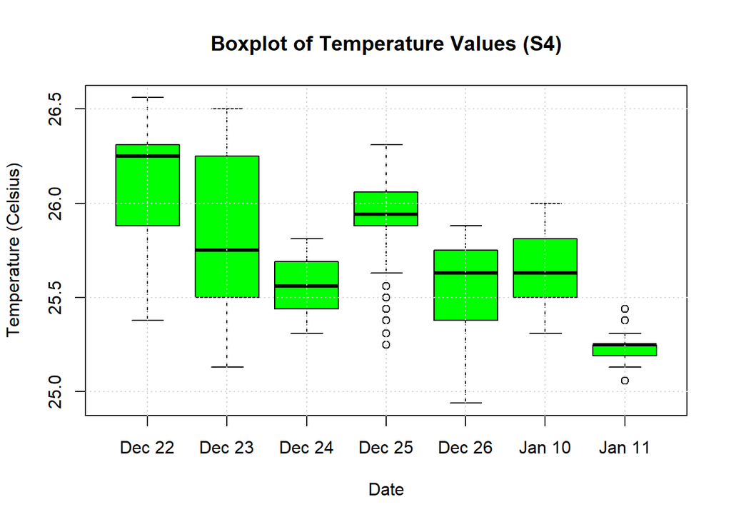

```r
boxplot(occupancy_estimation$S4_Temp ~ occupancy_estimation$Date,
        names=c("Dec 22","Dec 23", "Dec 24", "Dec 25", "Dec 26", "Jan 10", "Jan 11"),
        col=c("green"),
        xlab = "Date", ylab = "Temperature (Celsius)", main="Boxplot of Temperature Values (S4)" )
grid()
```

Create a boxplot to display the distribution of light values each day

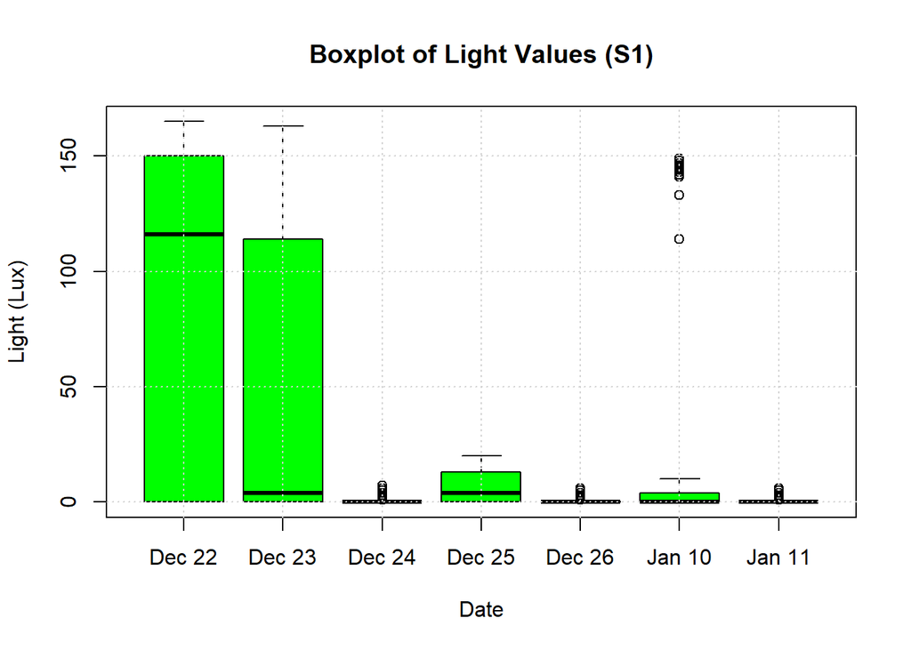

```r
# Create the boxplots

boxplot(occupancy_estimation$S1_Light ~ occupancy_estimation$Date,
        names=c("Dec 22","Dec 23", "Dec 24", "Dec 25", "Dec 26", "Jan 10", "Jan 11"),
        col=c("green"),
        xlab = "Date", ylab = "Light (Lux)", main="Boxplot of Light Values (S1)" )
grid()
```

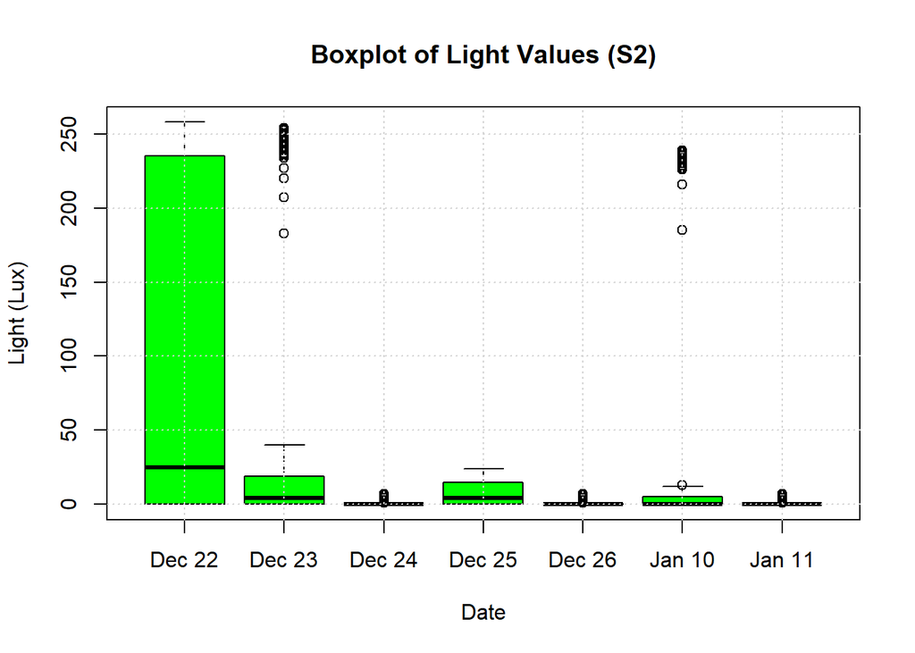

```r
boxplot(occupancy_estimation$S2_Light ~ occupancy_estimation$Date,
        names=c("Dec 22","Dec 23", "Dec 24", "Dec 25", "Dec 26", "Jan 10", "Jan 11"),
        col=c("green"),
        xlab = "Date", ylab = "Light (Lux)", main="Boxplot of Light Values (S2)" )
grid()
```

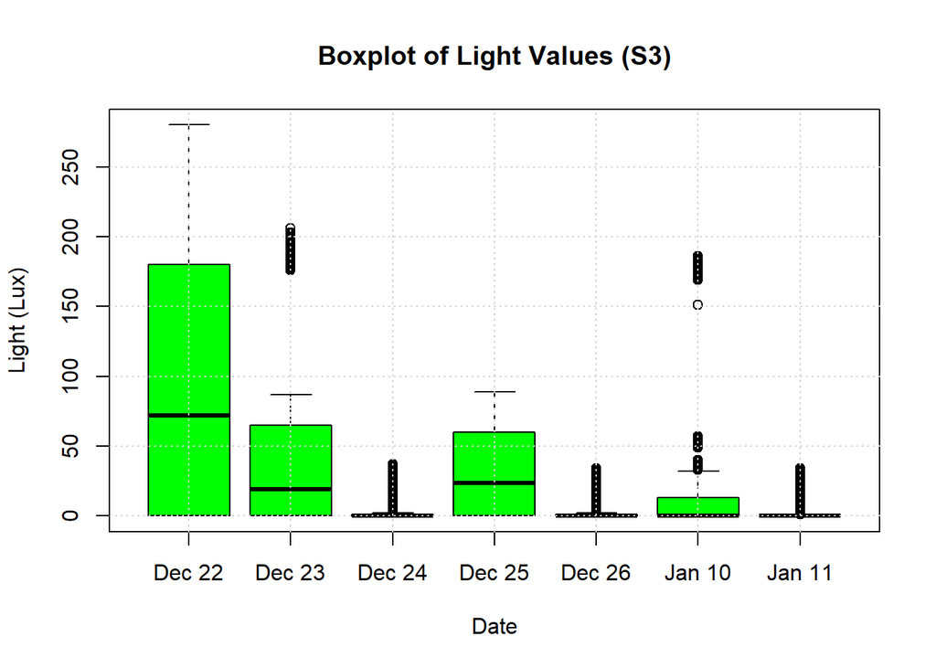

```r
boxplot(occupancy_estimation$S3_Light ~ occupancy_estimation$Date,
        names=c("Dec 22","Dec 23", "Dec 24", "Dec 25", "Dec 26", "Jan 10", "Jan 11"),
        col=c("green"),
        xlab = "Date", ylab = "Light (Lux)", main="Boxplot of Light Values (S3)" )
grid()
```

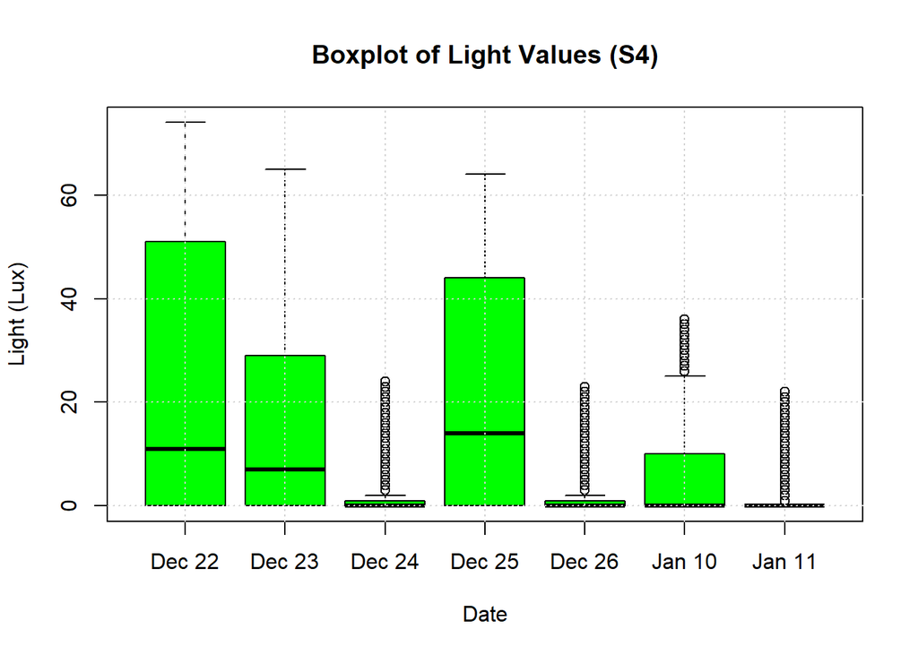

```r
boxplot(occupancy_estimation$S4_Light ~ occupancy_estimation$Date,
        names=c("Dec 22","Dec 23", "Dec 24", "Dec 25", "Dec 26", "Jan 10", "Jan 11"),
        col=c("green"),
        xlab = "Date", ylab = "Light (Lux)", main="Boxplot of Light Values (S4)" )
grid()
```

Create a boxplot to display the distribution of sound values each day

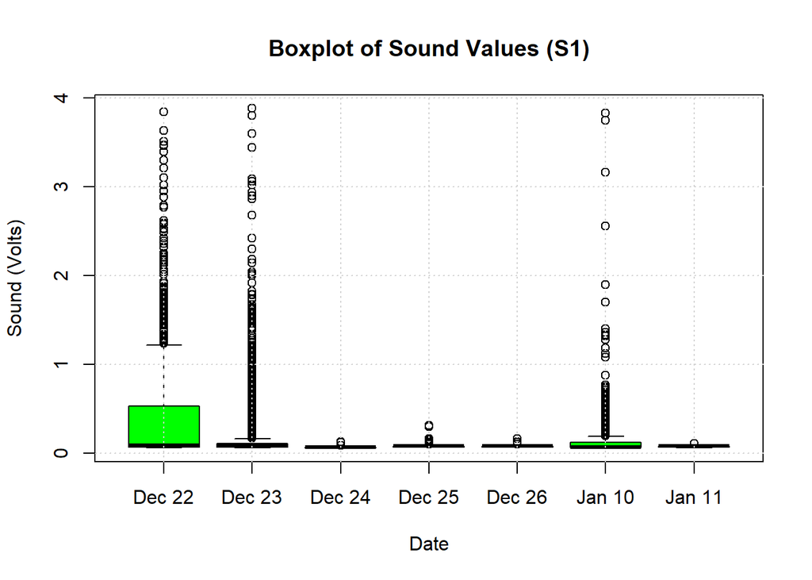

```r
# Create the boxplots

boxplot(occupancy_estimation$S1_Sound ~ occupancy_estimation$Date,
        names=c("Dec 22","Dec 23", "Dec 24", "Dec 25", "Dec 26", "Jan 10", "Jan 11"),
        col=c("green"),
        xlab = "Date", ylab = "Sound (Volts)", main="Boxplot of Sound Values (S1)" )
grid()
```

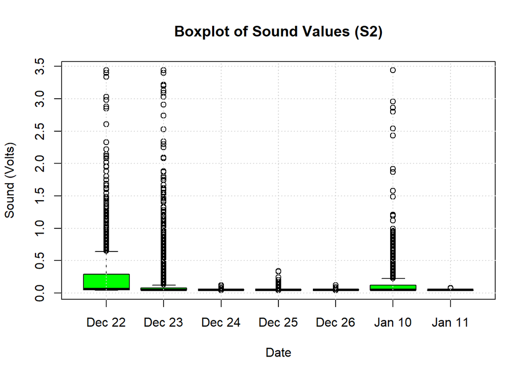

```r
boxplot(occupancy_estimation$S2_Sound ~ occupancy_estimation$Date,
        names=c("Dec 22","Dec 23", "Dec 24", "Dec 25", "Dec 26", "Jan 10", "Jan 11"),
        col=c("green"),
        xlab = "Date", ylab = "Sound (Volts)", main="Boxplot of Sound Values (S2)" )
grid()
```

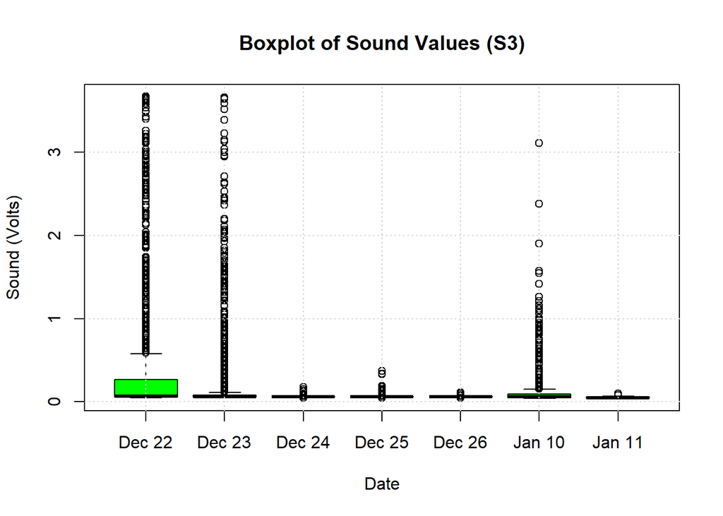

```r
boxplot(occupancy_estimation$S3_Sound ~ occupancy_estimation$Date,
        names=c("Dec 22","Dec 23", "Dec 24", "Dec 25", "Dec 26", "Jan 10", "Jan 11"),
        col=c("green"),
        xlab = "Date", ylab = "Sound (Volts)", main="Boxplot of Sound Values (S3)" )
grid()
```

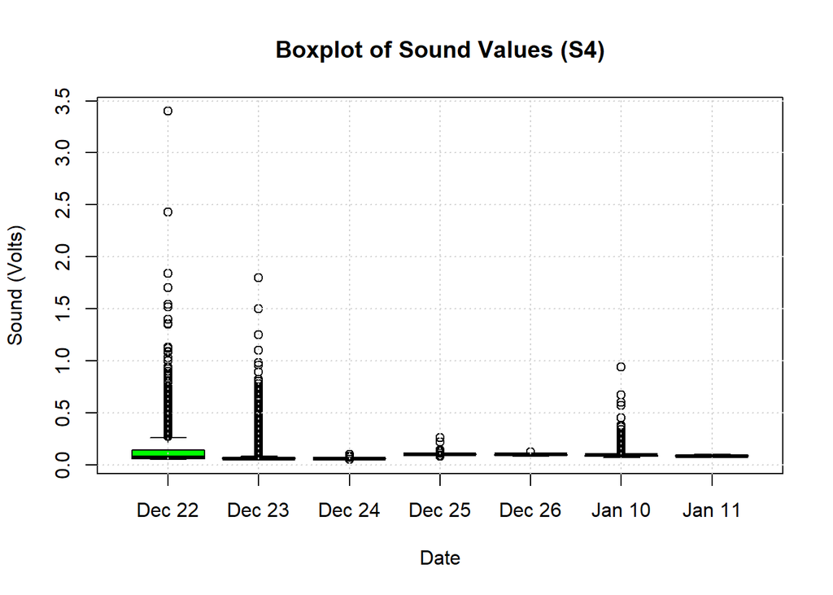

```r
boxplot(occupancy_estimation$S4_Sound ~ occupancy_estimation$Date,
        names=c("Dec 22","Dec 23", "Dec 24", "Dec 25", "Dec 26", "Jan 10", "Jan 11"),
        col=c("green"),
        xlab = "Date", ylab = "Sound (Volts)", main="Boxplot of Sound Values (S4)" )
grid()
```

Display the correlation matrix of the room occupancy and temperature variables of the data set

```r
# Extract the room occupancy and temperature variables of the data set
df_temp <- occupancy_estimation[ , c('Occupancy_Count', 'S1_Temp', 'S2_Temp', 'S3_Temp', 'S4_Temp')]

# Display the correlation matrix
cor(df_temp, method="spearman")
```

```
##                 Occupancy_Count   S1_Temp   S2_Temp   S3_Temp   S4_Temp
## Occupancy_Count       1.0000000 0.5889666 0.5472816 0.5584982 0.5284010
## S1_Temp               0.5889666 1.0000000 0.9699287 0.9506867 0.8651832
## S2_Temp               0.5472816 0.9699287 1.0000000 0.9338852 0.8430893
## S3_Temp               0.5584982 0.9506867 0.9338852 1.0000000 0.8979692
## S4_Temp               0.5284010 0.8651832 0.8430893 0.8979692 1.0000000
```

Display the correlation matrix of the room occupancy and light variables of the data set

```r
# Extract the room occupancy and temperature variables of the data set
df_light <- occupancy_estimation[ , c('Occupancy_Count', 'S1_Light', 'S2_Light', 'S3_Light', 'S4_Light')]

# Display the correlation matrix
cor(df_light, method="spearman")
```

```
##                 Occupancy_Count  S1_Light  S2_Light  S3_Light  S4_Light
## Occupancy_Count       1.0000000 0.7190518 0.7132504 0.6620569 0.4990386
## S1_Light              0.7190518 1.0000000 0.9982857 0.9688598 0.9280072
## S2_Light              0.7132504 0.9982857 1.0000000 0.9689215 0.9307378
## S3_Light              0.6620569 0.9688598 0.9689215 1.0000000 0.9376417
## S4_Light              0.4990386 0.9280072 0.9307378 0.9376417 1.0000000
```

Display the correlation matrix of the room occupancy and sound variables of the data set

```r
# Extract the room occupancy and sound variables of the data set
df_sound <- occupancy_estimation[ , c('Occupancy_Count', 'S1_Sound', 'S2_Sound', 'S3_Sound', 'S4_Sound')]

# Display the correlation matrix
cor(df_sound, method="spearman")
```

```
##                 Occupancy_Count  S1_Sound  S2_Sound  S3_Sound  S4_Sound
## Occupancy_Count       1.0000000 0.6391941 0.6745464 0.6485570 0.3601131
## S1_Sound              0.6391941 1.0000000 0.5298291 0.5050027 0.4749553
## S2_Sound              0.6745464 0.5298291 1.0000000 0.5976582 0.3109073
## S3_Sound              0.6485570 0.5050027 0.5976582 1.0000000 0.2838732
## S4_Sound              0.3601131 0.4749553 0.3109073 0.2838732 1.0000000
```

Display the correlation matrix of the room occupancy, CO2, and motion variables of the data set

```r
# Extract the room occupancy and CO2 variables of the data set
df_co2 <- occupancy_estimation[ , c('Occupancy_Count','S5_CO2', 'S5_CO2_Slope', 'S6_PIR', 'S7_PIR')]

# Display the correlation matrix
cor(df_co2, method="spearman")
```

```
##                 Occupancy_Count     S5_CO2 S5_CO2_Slope    S6_PIR    S7_PIR
## Occupancy_Count       1.0000000 0.58102341   0.54312686 0.6455547 0.6376658
## S5_CO2                0.5810234 1.00000000   0.01171331 0.3768087 0.3897880
## S5_CO2_Slope          0.5431269 0.01171331   1.00000000 0.3541037 0.3699864
## S6_PIR                0.6455547 0.37680872   0.35410366 1.0000000 0.5711250
## S7_PIR                0.6376658 0.38978803   0.36998640 0.5711250 1.0000000
```

Visualize the correlation plot

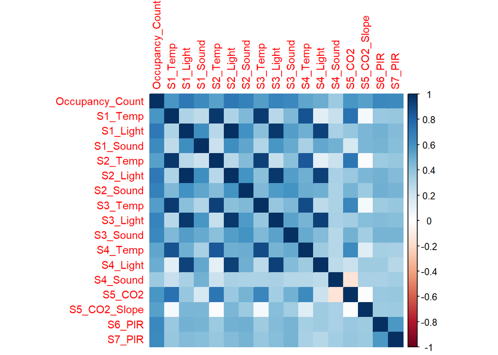

```r
library("corrplot")
# Extract the room occupancy and sensor data of the data set
df <- occupancy_estimation[ , c('Occupancy_Count', 'S1_Temp', 'S1_Light', 'S1_Sound',
                                'S2_Temp', 'S2_Light', 'S2_Sound',
                                'S3_Temp', 'S3_Light', 'S3_Sound',
                                'S4_Temp', 'S4_Light', 'S4_Sound',
                                'S5_CO2', 'S5_CO2_Slope', 'S6_PIR', 'S7_PIR')]

correlation_matrix <- cor(df, method="spearman")

# Visualize the correlation matrix
corrplot(correlation_matrix, method = 'color', tl.cex = 0.9)
```

[output not shown]